# Manager Salary Data Project

## We Begin by asking the following Questions:

Which industry pays the most?  
How does salary increase given years of experience?  
How do salaries compare for the same role in different locations?  
How much do salaries differ by gender and years of experience?  
How do factors like race and education level correlate with salary?

### 1. Load the Data

```r
library(readxl)
df <- read_excel("Ask A Manager Salary Survey 2021 (Responses).xlsx")
colofnames = c("Timestamp", "Age_Range", "Industry", "Title", "Title_Context", "Annual_Salary", "Additional_Compensation", "Currency", "Other_Currency", "Additional_Income_Context", "Country_of_Work", "US_State", "City", "Overall_Work_Experience", "Work_Experience_in_Field", "Highest_Level_of_Education", "Gender", "Race")
df <- as.data.frame(df)

colnames(df) <- colofnames

df
```

| Timestamp | Age_Range | Industry | Title | Title_Context | Annual_Salary | Additional_Compensation | Currency | Other_Currency | Additional_Income_Context | Country_of_Work | US_State | City | Overall_Work_Experience | Work_Experience_in_Field | Highest_Level_of_Education | Gender | Race |
| --- | --- | --- | --- | --- | --- | --- | --- | --- | --- | --- | --- | --- | --- | --- | --- | --- | --- |
| 2021-04-27 11:02:09 | 25-34 | Education (Higher Education) | Research and Instruction Librarian | NA | 55000 | 0.0 | USD | NA | NA | United States | Massachusetts | Boston | 5-7 years | 5-7 years | Master's degree | Woman | White |
| 2021-04-27 11:02:21 | 25-34 | Computing or Tech | Change & Internal Communications Manager | NA | 54600 | 4000.0 | GBP | NA | NA | United Kingdom | NA | Cambridge | 8 - 10 years | 5-7 years | College degree | Non-binary | White |
| 2021-04-27 11:02:38 | 25-34 | Accounting, Banking & Finance | Marketing Specialist | NA | 34000 | NA | USD | NA | NA | US | Tennessee | Chattanooga | 2 - 4 years | 2 - 4 years | College degree | Woman | White |
| 2021-04-27 11:02:40 | 25-34 | Nonprofits | Program Manager | NA | 62000 | 3000.0 | USD | NA | NA | USA | Wisconsin | Milwaukee | 8 - 10 years | 5-7 years | College degree | Woman | White |
| 2021-04-27 11:02:41 | 25-34 | Accounting, Banking & Finance | Accounting Manager | NA | 60000 | 7000.0 | USD | NA | NA | US | South Carolina | Greenville | 8 - 10 years | 5-7 years | College degree | Woman | White |
| 2021-04-27 11:02:45 | 25-34 | Education (Higher Education) | Scholarly Publishing Librarian | NA | 62000 | NA | USD | NA | NA | USA | New Hampshire | Hanover | 8 - 10 years | 2 - 4 years | Master's degree | Man | White |
| 2021-04-27 11:02:50 | 25-34 | Publishing | Publishing Assistant | NA | 33000 | 2000.0 | USD | NA | NA | USA | South Carolina | Columbia | 2 - 4 years | 2 - 4 years | College degree | Woman | White |
| 2021-04-27 11:02:59 | 25-34 | Education (Primary/Secondary) | Librarian | High school, FT | 50000 | NA | USD | NA | NA | United States | Arizona | Yuma | 5-7 years | 5-7 years | Master's degree | Man | White |
| 2021-04-27 11:03:01 | 45-54 | Computing or Tech | Systems Analyst | Data developer/ETL Developer | 112000 | 10000.0 | USD | NA | NA | US | Missouri | St. Louis | 21 - 30 years | 21 - 30 years | College degree | Woman | White |
| 2021-04-27 11:03:01 | 35-44 | Accounting, Banking & Finance | Senior Accountant | NA | 45000 | 0.0 | USD | NA | I work for a Charter School | United States | Florida | Palm Coast | 21 - 30 years | 21 - 30 years | College degree | Woman | Hispanic, Latino, or Spanish origin, White |

[output cut: 990 more lines]

### 2. Handle Nulls

```r
colSums(is.na(df))
```

```
                 Timestamp                  Age_Range                   Industry
                         0                          0                         74
                     Title              Title_Context              Annual_Salary
                         0                      20820                          0
   Additional_Compensation                   Currency             Other_Currency
                      7302                          0                      27859
 Additional_Income_Context            Country_of_Work                   US_State
                     25023                          0                       5024
                      City    Overall_Work_Experience   Work_Experience_in_Field
                         9                          0                          0
Highest_Level_of_Education                     Gender                       Race
                       222                        171                        177
```

For our purposes, we do not care about the “Title Context” column. We can also ignore the Additional Income Context column as most cases do not feature this, and they vary from company to company. Will most likely not provide any meaningful context to our data. Most of the other NAs can be handled through column combination, adding an “N/A” or “None”

We can begin by observing that both salary and additional compensation are integers. Thus, we can change any missing value to a 0, then sum the two values into its own column

```r
library(tidyverse)

df$Annual_Salary <- as.integer(df$Annual_Salary)
df = df %>% mutate(Industry = replace_na(Industry, "Other"))

df$Additional_Compensation <- as.integer(df$Additional_Compensation)

df = df %>% mutate(Additional_Compensation = replace_na(Additional_Compensation, 0))

df
```

| Timestamp | Age_Range | Industry | Title | Title_Context | Annual_Salary | Additional_Compensation | Currency | Other_Currency | Additional_Income_Context | Country_of_Work | US_State | City | Overall_Work_Experience | Work_Experience_in_Field | Highest_Level_of_Education | Gender | Race |
| --- | --- | --- | --- | --- | --- | --- | --- | --- | --- | --- | --- | --- | --- | --- | --- | --- | --- |
| 2021-04-27 11:02:09 | 25-34 | Education (Higher Education) | Research and Instruction Librarian | NA | 55000 | 0 | USD | NA | NA | United States | Massachusetts | Boston | 5-7 years | 5-7 years | Master's degree | Woman | White |
| 2021-04-27 11:02:21 | 25-34 | Computing or Tech | Change & Internal Communications Manager | NA | 54600 | 4000 | GBP | NA | NA | United Kingdom | NA | Cambridge | 8 - 10 years | 5-7 years | College degree | Non-binary | White |
| 2021-04-27 11:02:38 | 25-34 | Accounting, Banking & Finance | Marketing Specialist | NA | 34000 | 0 | USD | NA | NA | US | Tennessee | Chattanooga | 2 - 4 years | 2 - 4 years | College degree | Woman | White |
| 2021-04-27 11:02:40 | 25-34 | Nonprofits | Program Manager | NA | 62000 | 3000 | USD | NA | NA | USA | Wisconsin | Milwaukee | 8 - 10 years | 5-7 years | College degree | Woman | White |
| 2021-04-27 11:02:41 | 25-34 | Accounting, Banking & Finance | Accounting Manager | NA | 60000 | 7000 | USD | NA | NA | US | South Carolina | Greenville | 8 - 10 years | 5-7 years | College degree | Woman | White |
| 2021-04-27 11:02:45 | 25-34 | Education (Higher Education) | Scholarly Publishing Librarian | NA | 62000 | 0 | USD | NA | NA | USA | New Hampshire | Hanover | 8 - 10 years | 2 - 4 years | Master's degree | Man | White |
| 2021-04-27 11:02:50 | 25-34 | Publishing | Publishing Assistant | NA | 33000 | 2000 | USD | NA | NA | USA | South Carolina | Columbia | 2 - 4 years | 2 - 4 years | College degree | Woman | White |
| 2021-04-27 11:02:59 | 25-34 | Education (Primary/Secondary) | Librarian | High school, FT | 50000 | 0 | USD | NA | NA | United States | Arizona | Yuma | 5-7 years | 5-7 years | Master's degree | Man | White |
| 2021-04-27 11:03:01 | 45-54 | Computing or Tech | Systems Analyst | Data developer/ETL Developer | 112000 | 10000 | USD | NA | NA | US | Missouri | St. Louis | 21 - 30 years | 21 - 30 years | College degree | Woman | White |
| 2021-04-27 11:03:01 | 35-44 | Accounting, Banking & Finance | Senior Accountant | NA | 45000 | 0 | USD | NA | I work for a Charter School | United States | Florida | Palm Coast | 21 - 30 years | 21 - 30 years | College degree | Woman | Hispanic, Latino, or Spanish origin, White |

[output cut: 990 more lines]

```r
# Create new column that adds annual salary and compensation to one value
df$TotalSalary <- rowSums(df[,c("Annual_Salary", "Additional_Compensation")])

# Check for Remaining NAs
colSums(is.na(df))
```

```
                 Timestamp                  Age_Range                   Industry
                         0                          0                          0
                     Title              Title_Context              Annual_Salary
                         0                      20820                          1
   Additional_Compensation                   Currency             Other_Currency
                         0                          0                      27859
 Additional_Income_Context            Country_of_Work                   US_State
                     25023                          0                       5024
                      City    Overall_Work_Experience   Work_Experience_in_Field
                         9                          0                          0
Highest_Level_of_Education                     Gender                       Race
                       222                        171                        177
               TotalSalary
                         1
```

```r
df <- df %>% filter(!is.na(df$TotalSalary))
sum(is.na(df$TotalSalary))
```

```
[1] 0
```

There is 1 NA in the Total Salary and Annual Salary field. This is due to the number in the data set being so absurdly high that it is being recorded as an NA. We can treat this response as fake and drop it from our data set

Now we handle NAs in the US State field

```r
df = df %>% mutate(US_State = replace_na(US_State, "N/A"))
```

The 9 city null values provide a small subset that is not significantly large enough to matter. Thus, if we were to do analysis at a city level, we would omit these 9. Now for Highest Level of Education

```r
df = df %>% mutate(Highest_Level_of_Education = replace_na(Highest_Level_of_Education, "Non-Response"))
```

```r
# For Gender
df = df %>% mutate(Gender = replace_na(Gender, "Non-Response"))
```

```r
# For Race
df = df %>% mutate(Race = replace_na(Race, "Non-Response"))
```

### 3. Cleaning Messy Data

Now we observe the currencies that we have as a list

What we are looking for is how many different currencies we have a significant sample size of (>25 or >30 depending on preference) to be able to draw conclusions

```r
# Begin by finding all unique currencies
list_currency <- function(currency_column) {
  unique_currencies <- unique(currency_column)
  return(unique_currencies)
}

list_currency(df$Currency)
```

```
 [1] "USD"     "GBP"     "CAD"     "EUR"     "AUD/NZD" "Other"   "CHF"
 [8] "ZAR"     "SEK"     "HKD"     "JPY"
```

```r
# Check the other currency column
df %>%  select(Title, Country_of_Work,Currency, Other_Currency) %>% filter(complete.cases(.))
```

| Title | Country_of_Work | Currency | Other_Currency |
| --- | --- | --- | --- |
| Payment Services Officer | Canada | CAD | N/A |
| Data analyst | India | Other | INR |
| Exec admin | Argentina | Other | Peso Argentino |
| Administrative Librarian | USA | USD | 76302.34 |
| Lead Payroll & Benefits Specialist | US | USD | My bonus is based on performance up to 10% of salary |
| Sr Technical Support Rep | USA | USD | I work for an online state university, managing admissions data. Not direct tech support. |
| HR Manager/Accounts Payable | US | USD | 0.0 |
| HR Operations Manager | US | USD | N/A |
| Associate | Malaysia | Other | MYR |
| Consultant | Switzerland | Other | CHF |

[output cut: 206 more lines]

The Other Currency Column is extremely messy. There are only 216 rows so one option is to remove these entries. Another option is to create a new column where the currency is listed as it is in the currency column, then, if “Other” was listed, we list the other currency

```r
df$new_currency <- ifelse(df$Currency == "Other", df$Other_Currency, df$Currency)

# For Data Frame Checking
#df$new_currency
#list_currency(df$new_currency)

currency_counts <- table(df$new_currency)
print(currency_counts)
```

```
        American Dollars           Argentine Peso   Argentinian peso (ARS)
                       1                        1                        1
                     ARS                      AUD           AUD Australian
                       2                        3                        1
                 AUD/NZD       Australian Dollars                      Bdt
                     504                        1                        1
                     BR$                      BRL                 BRL (R$)
                       1                        6                        1
                     CAD                      CHF                China RMB
                    1673                       38                        1
                     CNY                      COP            croatian kuna
                       2                        1                        1
            czech crowns                      Czk                      CZK
                       1                        1                        4
           Danish Kroner                      dkk                      Dkk
                       1                        1                        2
                     DKK                   Equity                      EUR
                       8                        1                      644
                    Euro                      GBP                      HKD
                       1                     1593                        4
                     IDR                      Ils                      ILS
                       2                        1                        2
            ILS (Shekel)                  ILS/NIS            Indian rupees
                       1                        1                        1
                     INR       INR (Indian Rupee)          Israeli Shekels
                      11                        1                        1
                     JPY               Korean Won                      KRW
                      23                        1                        2
        KRW (Korean Won)                      LKR            Mexican pesos
                       1                        1                        1
           Mexican Pesos                      MXN                      MYR
                       1                        2                        8
                     NGN NIS (new Israeli shekel)                      Nok
                       2                        1                        1
                     NOK   Norwegian kroner (NOK)                      NTD
                       8                        1                        2
                     NZD           Peso Argentino          Philippine Peso
                       2                        1                        1
   Philippine peso (PHP)         Philippine Pesos                      Php
                       1                        1                        1
                     PHP    PhP (Philippine Peso)                      PLN
                       1                        1                        5
      PLN (Polish zloty)              PLN (Zwoty)             Polish Złoty
                       1                        1                        1
                      RM       RMB (chinese yuan)                   Rupees
                       1                        1                        1
                     SAR                      SEK                      Sgd
                       1                       38                        1
                     SGD        Singapore Dollara        Taiwanese dollars
                      11                        1                        1
              THAI  BAHT                Thai Baht                      THB
                       1                        1                        2
                     TRY                      TTD                US Dollar
                       2                        1                        1
                     USD                      ZAR
                   23395                       17
```

```r
usvariation = c("American Dollars", "US Dollar", "USD", "Equity")
ausvariation = c("AUD", "AUD Australian", "AUD/NZD", "Australian Dollars", "NZD")
eurvariation = c("EUR","Euro")
```

Above are the variations of the only combinations that provide us with a large enough sample size to give us meaningful insight Thus, in our data frame we can combine these variations into consistent classifications

```r
df <- df %>%
  mutate(cleaned_currency = case_when(
    new_currency %in% usvariation ~ "USD",
    new_currency %in% ausvariation ~ "AUD",
    new_currency %in% eurvariation ~ "EUR",
    TRUE ~ new_currency  # Leave other currency unchanged
  ))

currency_counts <- table(df$cleaned_currency)
currency_df <- as.data.frame(currency_counts)

# Rename columns for clarity
colnames(currency_df) <- c("currency", "frequency")

# Filter rows where frequency > 25
filtered_df <- currency_df[currency_df$frequency > 25, ]

# Sort by frequency in descending order
sorted_df <- filtered_df[order(-filtered_df$frequency), ]

# View the result
print(sorted_df)
```

|  | currency | frequency |
| --- | --- | --- |
| 74 | USD | 23398 |
| 9 | CAD | 1673 |
| 23 | GBP | 1593 |
| 22 | EUR | 645 |
| 4 | AUD | 511 |
| 10 | CHF | 38 |
| 64 | SEK | 38 |

Now we trim our data down to only those who use USD, AUD, CAD, EUR, GBP, SEK, and CHF as these are the samples n > 30.

```r
wanted_currencies = c("USD", "AUD", "EUR", "GBP", "CAD", "SEK", "CHF")

workingdf <- df %>%  select(Age_Range, Industry, Title, Title_Context, Country_of_Work, US_State, City, Overall_Work_Experience, Work_Experience_in_Field, Highest_Level_of_Education, Gender, Race, TotalSalary, cleaned_currency) %>% filter(cleaned_currency %in% wanted_currencies)

# For Data Frame Checking
#workingdf
```

Now we translate all currencies to USD. Since this is for project purposes I will be using a static method for conversion rates An Automatic conversion rate could be coded using an API and API keys

```r
conversion_rates = c("USD" = 1, "CAD" = 0.74, "EUR" = 1.12, "AUD" = 0.68, "SEK" = 0.098, "CHF" = 1.18, "GBP" = 1.34)

convert_salary_to_usd <- function(salary, currency) {
  return(salary * conversion_rates[currency])
}

workingdf <- workingdf %>%
  mutate(TranslatedSalary = mapply(convert_salary_to_usd, TotalSalary, cleaned_currency))

#workingdf
```

Now we have fully translated to USD salaries and are able to begin analyzing salary data. We can now check other columns for abnormalities

```r
newdf <- workingdf %>% select(Age_Range, Industry, Title, Title_Context, Country_of_Work, US_State, City, Overall_Work_Experience, Work_Experience_in_Field, Highest_Level_of_Education, Gender, Race, cleaned_currency, TotalSalary, TranslatedSalary)

colSums(is.na(newdf))
```

```
                 Age_Range                   Industry                      Title
                         0                          0                          0
             Title_Context            Country_of_Work                   US_State
                     20690                          0                          0
                      City    Overall_Work_Experience   Work_Experience_in_Field
                         9                          0                          0
Highest_Level_of_Education                     Gender                       Race
                         0                          0                          0
          cleaned_currency                TotalSalary           TranslatedSalary
                         0                          0                          0
```

```r
# Handle Industry Data Cleaning
newdf$Industry <- tolower(newdf$Industry)
industry_counts = table(newdf$Industry)

# I Commented the table; un-comment to view the messy results
#industry_counts
```

Unfortunately our Industry data is extremely messy.

However, we have enough here that we can exclude the other labelled fields and then select the proper sample size (>30) sectors

Let’s rewrite this code to solve in a vectorized format such that it will run faster and more efficiently

```r
library(dplyr)
library(stringdist)
# Function to extract potential keywords from a column of text values
extract_keywords <- function(text_column) {

  # Convert to lowercase for uniformity
  text_column <- tolower(text_column)

  # Remove special characters
  text_column <- gsub("[^a-zA-Z\\s]", "", text_column)

  # Split each entry into individual words
  words <- unlist(strsplit(text_column, "\\s+"))

  # Remove any empty strings (if present)
  words <- words[words != ""]

  # Count the frequency of each word
  word_freq <- table(words)

  # Convert to a sorted data frame for easier inspection
  keyword_df <- as.data.frame(sort(word_freq, decreasing = TRUE))
  colnames(keyword_df) <- c("keyword", "frequency")

  return(keyword_df)
}

add_keywords <- function(text_column) {

  # Convert to lowercase for uniformity
  text_column <- tolower(text_column)

  # Remove special characters (optional, but helpful for cleanup)
  text_column <- gsub("[^a-zA-Z\\s]", "", text_column)

  # Split each entry into individual words
  words <- unlist(strsplit(text_column, "\\s+"))

  # Remove any empty strings (if present)
  words <- words[words != ""]

  keyword_column <- words
  return(keyword_column)
}



potential_keywords <- extract_keywords(newdf$Industry)
#to view potential keywords
print(potential_keywords)
```

| keyword | frequency |
| --- | --- |
| computingortech | 4655 |
| educationhighereducation | 2454 |
| nonprofits | 2414 |
| healthcare | 1889 |
| governmentandpublicadministration | 1881 |
| accountingbankingfinance | 1802 |
| engineeringormanufacturing | 1683 |
| marketingadvertisingpr | 1123 |
| law | 1093 |
| businessorconsulting | 846 |

[output cut: 966 more lines]

```r
# Add Keywords to Data Frame

newdf$Keywords <- add_keywords(newdf$Industry)

newdf %>% select(Industry,Keywords)
```

| Industry | Keywords |
| --- | --- |
| education (higher education) | educationhighereducation |
| computing or tech | computingortech |
| accounting, banking & finance | accountingbankingfinance |
| nonprofits | nonprofits |
| accounting, banking & finance | accountingbankingfinance |
| education (higher education) | educationhighereducation |
| publishing | publishing |
| education (primary/secondary) | educationprimarysecondary |
| computing or tech | computingortech |
| accounting, banking & finance | accountingbankingfinance |

[output cut: 990 more lines]

Now we can filter our data set by high frequency.

We can choose a threshold for frequency to filter our data set into groups. Since there are many instances of frequencies in the range of 1-3, it might be too difficult to properly filter the data accurately into their groups. Using a matching algorithm such as fuzzy matching would be a possibility but due to its inexactness, it is better to take exact, significant sample sizes as opposed to risking a high error in sorting.

```r
filtered_df <- subset(potential_keywords, frequency >= 25)

# View the number of filtered entries
sum(filtered_df$frequency)
```

```
[1] 26260
```

```r
keywordarray = c()

# Add the keywords to an array
for(names in filtered_df$keyword){
  keywordarray <- c(keywordarray,names)
}

# Check keyword array
keywordarray
```

```
 [1] "computingortech"                   "educationhighereducation"
 [3] "nonprofits"                        "healthcare"
 [5] "governmentandpublicadministration" "accountingbankingfinance"
 [7] "engineeringormanufacturing"        "marketingadvertisingpr"
 [9] "law"                               "businessorconsulting"
[11] "educationprimarysecondary"         "mediadigital"
[13] "insurance"                         "retail"
[15] "recruitmentorhr"                   "propertyorconstruction"
[17] "artdesign"                         "utilitiestelecommunications"
[19] "transportorlogistics"              "sales"
[21] "socialwork"                        "hospitalityevents"
[23] "entertainment"                     "agricultureorforestry"
[25] "leisuresporttourism"               "other"
[27] "publishing"                        "library"
[29] "publiclibrary"                     "biotech"
[31] "libraries"                         "manufacturing"
[33] "lawenforcementsecurity"            "research"
[35] "pharmaceutical"                    "pharmaceuticals"
[37] "architecture"                      "realestate"
[39] "publiclibraries"
```

```r
# Assign a group to each keyword of frequency >= 25
keyworddf <- data.frame(
  Keywords = keywordarray,
  group = c("Technology","Higher Education","Non Profits","Health Care","Government","Financial Sector","Engineering & Manufacturing","Law","Marketing & Pr", "Business & Consulting","Primary/Secondary Education", "Media & Entertainment", "Insurance", "Retail", "HR", "Construction", "Art & Design", "Utilities", "Transportation", "Sales", "Social Work", "Hospitality", "Media & Entertainment", "Agriculture and Forestry", "Leisure & Tourism", "Miscellaneous", "Publishing","Library","Library","BioTech & Pharmaceuticals","Library","Engineering & Manufacturing","Law","Research","BioTech & Pharmaceuticals","Engineering & Manufacturing","BioTech & Pharmaceuticals", "Real Estate", "Library"),
  stringsAsFactors = FALSE
)

# Note: Do not run this chunk by itself multiple times, it breaks the left_join function
newdf <- newdf %>% left_join(keyworddf, by = "Keywords")
newdf <- newdf %>% mutate(group = coalesce(group, "Miscellaneous"))


newdf_with_groups <- newdf %>% select(Age_Range, Industry, Title, Country_of_Work, US_State, City, Overall_Work_Experience, Work_Experience_in_Field, Highest_Level_of_Education, Gender, Race, cleaned_currency, TranslatedSalary, group)

#View df
newdf_with_groups
```

Just need to clean the country column now

```r
#table(newdf_with_groups$`Country of Work`)
# Use the extract keywords function to extract countries
country_keywords <- extract_keywords(newdf_with_groups$Country_of_Work)

#Keyword Frequency Table
country_keywords
```

Once again we will use the mapping strategy

It does not make sense to go country by country since only a select few are of significant size to justify keeping

Using the information that we know, we can break these up and sort by original currency.

In that case, we have an America, Canada, Great Britain, Europe and Australia/New Zealand Region that will provide us with meaningful differences while not running the risk of a string matching function giving incorrect matches. In this case, we will place Sweden and Switzerland in the Europe section.

```r
regiondf = data.frame(
  cleaned_currency = wanted_currencies,
  Region = c("United States", "Australia", "Europe","Great Britain", "Canada", "Europe", "Europe"),
  stringsAsFactors = FALSE
)
newdf_with_groups <- merge(newdf_with_groups, regiondf, by = "cleaned_currency", all.x = TRUE)
```

One Last step we can take is to sort out all of the entries where USD was their listed currency but they are not US country Now, the country column being as bad as it is, we will lose some of the united states entries but, if we use our mapping strategy for the most common variants of the country, we can retain as many as possible

```r
#Filter for Keywrods beginning with U
Unitedstatesfreq <- country_keywords
Unitedstatesfreq <- Unitedstatesfreq %>% filter(grepl("^u", keyword))
Unitedstatesfreq <- Unitedstatesfreq %>% filter(!keyword %in% c("uk","unitedkingdom","uae","uganda","ukraine","unitedarabemirates"))

#check results
#Unitedstatesfreq

UnitedStatesSpellings <- Unitedstatesfreq$keyword
UnitedStatesSpellings
```

```r
normalize_country <- function(x) {
  x <- tolower(x)                      # Convert to lowercase
  x <- str_replace_all(x, "[^a-z]", "") # Remove non-alphabetic characters (special chars and spaces)
  return(x)
}

# Normalize the country column
newdf_with_groups$normalized_country <- normalize_country(newdf_with_groups$Country_of_Work)

# Replace the normalized variations (and the "America" variation)
newdf_with_groups$Country_of_Work[newdf_with_groups$normalized_country %in% UnitedStatesSpellings] <- "United States"
newdf_with_groups$Country_of_Work[newdf_with_groups$normalized_country == "america"] <- "United States"

# Drop the helper 'normalized_country' column
newdf_with_groups <- newdf_with_groups %>% select(-normalized_country)

# View the result
#newdf_with_groups %>% filter(Region == "United States" & `US State` == "N/A")

# Now we have that our country of work is United states if they are US
# This means we can now filter for region and know that our United States region entries are in the United States

Finaldf <- newdf_with_groups %>% filter(!Region == "United States" | (Region == "United States" & Country_of_Work == "United States"))
Finaldf <- Finaldf %>% select(-cleaned_currency)
Finaldf <- Finaldf %>% select(-Country_of_Work)
Finaldf <- Finaldf %>% select(-Industry)
Finaldf
```

We have now gone from a messy 28075 entry data set to a cleaned and organized 27662 entry data set; losing 413 entries in the process of cleaning or roughly 1.5% of entries. This should be considered an adequate amount of entries to lose in a data set this large.

### 4. Data Analysis

Let’s Look back to the original questions:

### Which industry pays the most?

How does salary increase given years of experience?  
How do salaries compare for the same role in different locations?  
How much do salaries differ by gender and years of experience?  
How do factors like race and education level correlate with salary?

```r
# Which industry pays the most?
# We begin by finding the top 5 industries by average and median
top_industries_mean <- Finaldf %>%
  group_by(group) %>%                          # Group data by 'Industry'
  summarise(
    mean_salary = mean(TranslatedSalary, na.rm = TRUE), # Calculate mean salary
  ) %>%
  arrange(desc(mean_salary)) %>% slice_head(n=5)
  # Sort by mean salary in descending order

top_industries_median <- Finaldf %>%
  group_by(group) %>%                          # Group data by 'Industry'
  summarise(
    median_salary = median(TranslatedSalary, na.rm = TRUE) # Calculate median salary
  ) %>%
  arrange(desc(median_salary)) %>% slice_head(n=5)

top_industries_mean
top_industries_median

meanFinaldf <- Finaldf %>% filter(group %in% top_industries_mean$group)
medianFinaldf <- Finaldf %>% filter(group %in% top_industries_median$group)



boxplot(TranslatedSalary ~ group, meanFinaldf)
#we have an issue with outliers, clearly.
```

[output not shown]

```r
# See how it affects our top 5
df_capped_mean <- meanFinaldf %>%
  mutate(
    TranslatedSalary = ifelse(TranslatedSalary < 0, 0, TranslatedSalary),
    TranslatedSalary = ifelse(TranslatedSalary > 500000, 500000, TranslatedSalary)
  )

df_capped_med <- medianFinaldf %>%
  mutate(
    TranslatedSalary = ifelse(TranslatedSalary < 0, 0, TranslatedSalary),
    TranslatedSalary = ifelse(TranslatedSalary > 500000, 500000, TranslatedSalary)
  )

top_industries_mean <- df_capped_mean %>%
  group_by(group) %>%
  summarise(
    mean_salary = mean(TranslatedSalary, na.rm = TRUE),
  ) %>%
  arrange(desc(mean_salary)) %>% slice_head(n=5)


top_industries_median <- df_capped_med %>%
  group_by(group) %>%
  summarise(
    median_salary = median(TranslatedSalary, na.rm = TRUE)
  ) %>%
  arrange(desc(median_salary)) %>% slice_head(n=5)

top_industries_mean
```

| group | mean_salary |
| --- | --- |
| Technology | 139337.6 |
| Marketing & Pr | 126691.0 |
| BioTech & Pharmaceuticals | 112579.2 |
| Business & Consulting | 110239.4 |
| Sales | 103732.7 |

```r
top_industries_median
```

| group | median_salary |
| --- | --- |
| Technology | 120000.00 |
| BioTech & Pharmaceuticals | 105000.00 |
| Marketing & Pr | 96000.00 |
| Business & Consulting | 93358.56 |
| Engineering & Manufacturing | 91000.00 |

Here we see that the order of our top 5 by mean changes, but as a whole, our top 5 industries by mean stay the same. Median, of course, would not be affected

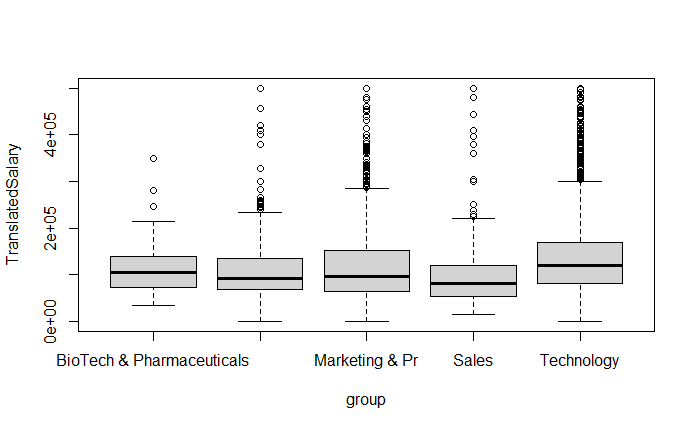

```r
boxplot(TranslatedSalary ~ group, df_capped_mean)
```

Lets try this instead with setting our bounds to 1.5 times IQR

```r
Q1 <- quantile(meanFinaldf$TranslatedSalary, 0.25, na.rm = TRUE)
Q3 <- quantile(meanFinaldf$TranslatedSalary, 0.75, na.rm = TRUE)
IQR <- Q3 - Q1

# Define outliers as points outside 1.5 * IQR from the quartiles
lower_bound <- Q1 - 1.5 * IQR
upper_bound <- Q3 + 1.5 * IQR


df_capped_mean <- meanFinaldf %>%
  mutate(
    TranslatedSalary = ifelse(TranslatedSalary < lower_bound, lower_bound, TranslatedSalary),
    TranslatedSalary = ifelse(TranslatedSalary > upper_bound, upper_bound, TranslatedSalary)
  )

df_capped_med <- medianFinaldf %>%
  mutate(
    TranslatedSalary = ifelse(TranslatedSalary < lower_bound, lower_bound, TranslatedSalary),
    TranslatedSalary = ifelse(TranslatedSalary > upper_bound, upper_bound, TranslatedSalary)
  )
boxplot(TranslatedSalary ~ group, df_capped_mean)
boxplot(TranslatedSalary ~ group, df_capped_med)
```

[output not shown]

```r
# Checking ANOVA, Kruskal-Wallis and Tukey
result <- aov(TranslatedSalary ~ group, data = df_capped_mean)
summary(result)
```

```
              Df    Sum Sq   Mean Sq F value Pr(>F)
group          4 9.439e+11 2.360e+11   32.69 <2e-16 ***
Residuals   6918 4.994e+13 7.218e+09
---
Signif. codes:  0 ‘***’ 0.001 ‘**’ 0.01 ‘*’ 0.05 ‘.’ 0.1 ‘ ’ 1
```

```r
shapiro.test(sample(meanFinaldf$TranslatedSalary,5000))
```

```
    Shapiro-Wilk normality test

data:  sample(meanFinaldf$TranslatedSalary, 5000)
W = 0.48676, p-value < 2.2e-16
```

```r
kruskal.test(TranslatedSalary ~ group, data = df_capped_mean)
```

```
    Kruskal-Wallis rank sum test

data:  TranslatedSalary by group
Kruskal-Wallis chi-squared = 223.96, df = 4, p-value < 2.2e-16
```

```r
TUKEY <- TukeyHSD(result)
tukey_df <- as.data.frame(TUKEY$group)
tukey_significant <- tukey_df[tukey_df$`p adj` < 0.05, ]
tukey_significant
```

|  | diff | lwr | upr | p adj |
| --- | --- | --- | --- | --- |
| Technology-BioTech & Pharmaceuticals | 26758.41 | 4684.727 | 48832.086 | 8.399279e-03 |
| Marketing & Pr-Business & Consulting | 16451.64 | 5794.888 | 27108.399 | 2.479410e-04 |
| Technology-Business & Consulting | 29098.24 | 20391.596 | 37804.875 | 9.634515e-13 |
| Sales-Marketing & Pr | -22958.34 | -38428.640 | -7488.042 | 4.983960e-04 |
| Technology-Marketing & Pr | 12646.59 | 4828.941 | 20464.243 | 1.006782e-04 |
| Technology-Sales | 35604.93 | 21407.424 | 49802.443 | 8.535939e-11 |

Using the Tukey Test, we can see that when compared to all of the other industries in the top 5 by mean, the distribution of Technology is significantly different. Thus, we are able to conclude that Technology is the Industry that pays the best.

```r
result <- aov(TranslatedSalary ~ group, data = df_capped_med)
summary(result)
```

```
              Df    Sum Sq   Mean Sq F value Pr(>F)
group          4 2.146e+12 5.365e+11   85.47 <2e-16 ***
Residuals   8382 5.261e+13 6.277e+09
---
Signif. codes:  0 ‘***’ 0.001 ‘**’ 0.01 ‘*’ 0.05 ‘.’ 0.1 ‘ ’ 1
```

```r
shapiro.test(sample(medianFinaldf$TranslatedSalary,5000))
```

```
    Shapiro-Wilk normality test

data:  sample(medianFinaldf$TranslatedSalary, 5000)
W = 0.60958, p-value < 2.2e-16
```

```r
kruskal.test(TranslatedSalary ~ group, data = df_capped_med)
```

```
    Kruskal-Wallis rank sum test

data:  TranslatedSalary by group
Kruskal-Wallis chi-squared = 378.21, df = 4, p-value < 2.2e-16
```

```r
TUKEY <- TukeyHSD(x=result, conf.level=0.95)
TUKEY
```

```
  Tukey multiple comparisons of means
    95% family-wise confidence level

Fit: aov(formula = TranslatedSalary ~ group, data = df_capped_med)

$group
                                                            diff        lwr
Business & Consulting-BioTech & Pharmaceuticals        -2339.829 -24002.312
Engineering & Manufacturing-BioTech & Pharmaceuticals -11670.447 -32652.598
Marketing & Pr-BioTech & Pharmaceuticals               14111.814  -7253.823
Technology-BioTech & Pharmaceuticals                   26758.406   6175.461
Engineering & Manufacturing-Business & Consulting      -9330.618 -18413.863
Marketing & Pr-Business & Consulting                   16451.643   6514.586
Technology-Business & Consulting                       29098.235  20979.594
Marketing & Pr-Engineering & Manufacturing             25782.261  17431.657
Technology-Engineering & Manufacturing                 38428.853  32354.331
Technology-Marketing & Pr                              12646.592   5356.901
                                                            upr     p adj
Business & Consulting-BioTech & Pharmaceuticals       19322.654 0.9983585
Engineering & Manufacturing-BioTech & Pharmaceuticals  9311.704 0.5510044
Marketing & Pr-BioTech & Pharmaceuticals              35477.451 0.3723467
Technology-BioTech & Pharmaceuticals                  47341.352 0.0035952
Engineering & Manufacturing-Business & Consulting      -247.373 0.0406427
Marketing & Pr-Business & Consulting                  26388.701 0.0000623
Technology-Business & Consulting                      37216.877 0.0000000
Marketing & Pr-Engineering & Manufacturing            34132.866 0.0000000
Technology-Engineering & Manufacturing                44503.375 0.0000000
Technology-Marketing & Pr                             19936.283 0.0000221
```

```r
tukey_df <- as.data.frame(TUKEY$group)
tukey_significant <- tukey_df[tukey_df$`p adj` < 0.05, ]
tukey_significant
```

|  | diff | lwr | upr | p adj |
| --- | --- | --- | --- | --- |
| Technology-BioTech & Pharmaceuticals | 26758.406 | 6175.461 | 47341.352 | 3.595205e-03 |
| Engineering & Manufacturing-Business & Consulting | -9330.618 | -18413.863 | -247.373 | 4.064265e-02 |
| Marketing & Pr-Business & Consulting | 16451.643 | 6514.586 | 26388.701 | 6.231754e-05 |
| Technology-Business & Consulting | 29098.235 | 20979.594 | 37216.877 | 2.334244e-11 |
| Marketing & Pr-Engineering & Manufacturing | 25782.261 | 17431.657 | 34132.866 | 2.334211e-11 |
| Technology-Engineering & Manufacturing | 38428.853 | 32354.331 | 44503.375 | 2.329148e-11 |
| Technology-Marketing & Pr | 12646.592 | 5356.901 | 19936.283 | 2.214078e-05 |

Similar Results for median strengthens our result

### How does salary increase given years of experience?

We only have ranges for years of experience, not concrete numeric values We could choose to use the minimum of each threshold and plot correlation We also can once again use a box plot visualization to check for differences

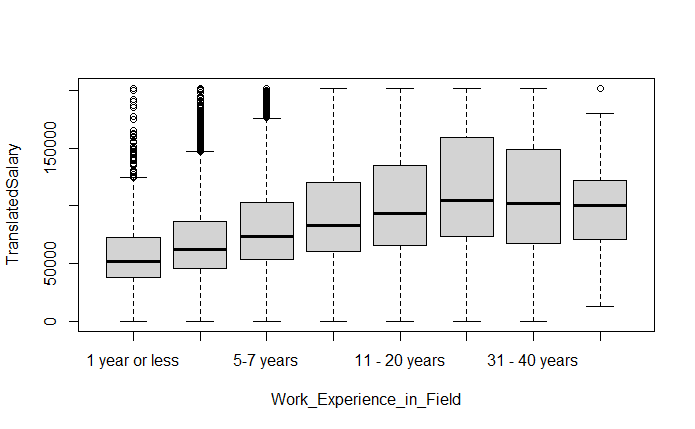

```r
Q1 <- quantile(Finaldf$TranslatedSalary, 0.25, na.rm = TRUE)
Q3 <- quantile(Finaldf$TranslatedSalary, 0.75, na.rm = TRUE)
IQR <- Q3 - Q1

# Define outliers as points outside 1.5 * IQR from the quantiles
lower_bound <- Q1 - 1.5 * IQR
upper_bound <- Q3 + 1.5 * IQR


Finaldf_capped <- Finaldf %>%
  mutate(
    TranslatedSalary = ifelse(TranslatedSalary < lower_bound, lower_bound, TranslatedSalary),  # Cap lower outliers
    TranslatedSalary = ifelse(TranslatedSalary > upper_bound, upper_bound, TranslatedSalary)   # Cap upper outliers
  )
#unique(Finaldf_capped$Work_Experience_in_Field)

Finaldf_capped$Work_Experience_in_Field <- factor(Finaldf_capped$Work_Experience_in_Field, levels = c("1 year or less", "2 - 4 years", "5-7 years", "8 - 10 years", "11 - 20 years", "21 - 30 years", "31 - 40 years", "41 years or more"))

#unique(Finaldf_capped$Work_Experience_in_Field)
boxplot(TranslatedSalary ~ Work_Experience_in_Field, Finaldf_capped)
```

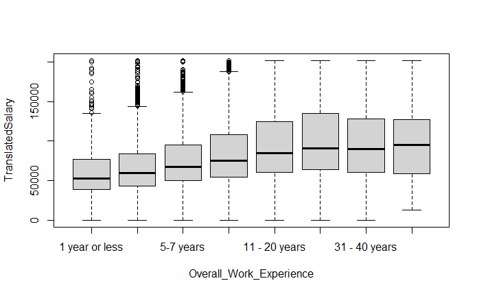

```r
#unique(Finaldf_capped$Overall_Work_Experience)

Finaldf_capped$Overall_Work_Experience <- factor(Finaldf_capped$Overall_Work_Experience, levels = c("1 year or less", "2 - 4 years", "5-7 years", "8 - 10 years", "11 - 20 years", "21 - 30 years", "31 - 40 years", "41 years or more"))


boxplot(TranslatedSalary ~ Overall_Work_Experience, Finaldf_capped)
```

We can see the median values increase steadily from the 1 year or less group to the 21-30 years experience before flattening out

If we care to get into specifics, we can once again use the Tukey test as we did above to check for differences between groups. However, for the purposes of this, we can see that up until around the 21-30 range, salary increases steadily before plateauing

### How do salaries compare for the same role in different locations?

For this we can use industry and region and compare Lets once again move back to our dataset of just the top 5 industries by mean

```r
result.aov <- aov(TranslatedSalary ~ group * Region, data = df_capped_mean)
tukey_result <- TukeyHSD(result.aov)
# interaction_term_results <- tukey_result$`group:Region`
#
# tukey_interaction_df <- as.data.frame(interaction_term_results)
#
# # Show significant results for Region (p-value < 0.05)
# significant_interaction <- tukey_interaction_df[tukey_interaction_df$`p adj` < 0.05, ]
#
# print(significant_interaction)

tukey_result <- TukeyHSD(result.aov)

tukey_df <- as.data.frame(tukey_result$`group:Region`)

# Add a column with the comparison labels
tukey_df$comparison <- rownames(tukey_df)

filter_same_industry_diff_region <- function(comp) {
  # Split the comparison label at the '-'
  split_comparison <- unlist(strsplit(comp, "-"))

  # Further split at ':' to separate industry and region
  industry_region_1 <- unlist(strsplit(split_comparison[1], ":"))
  industry_region_2 <- unlist(strsplit(split_comparison[2], ":"))

  # Check if the industries are the same and regions are different
  return(industry_region_1[1] == industry_region_2[1] && industry_region_1[2] != industry_region_2[2])
}

# Apply the filtering function to the comparison column
tukey_filtered <- tukey_df[sapply(tukey_df$comparison, filter_same_industry_diff_region), ]

# Display the filtered results
#print(tukey_filtered)

tukey_filtered_significant <- tukey_filtered[tukey_filtered$`p adj` < 0.05, ]

# Display the filtered results
print(tukey_filtered_significant)
```

```r
par(mfrow = c(2,3))
for(i in 1:5){
techgroup <- subset(df_capped_mean, group == top_industries_mean$group[i])
boxplot(TranslatedSalary ~ Region, techgroup, las=2)
title(main = top_industries_mean$group[i])
}
```

[output not shown]

Our next question was: How much do salaries differ by gender and years of experience? This question is actually solved in the similar processes as before with box plots and tukey tests, thus we move on to our last question

### How do factors like race and education level correlate with salary?

We solve this by creating a linear model

```r
model <- lm(TranslatedSalary ~ Age_Range + group + Region + Race + Gender + Highest_Level_of_Education + Overall_Work_Experience + Work_Experience_in_Field, data = Finaldf_capped)
#summary(model)
#Not a very useful output

# Sort for race that is more frequent, will not account for
race_counts <- table(Finaldf_capped$Race)
#print(race_counts)

race_counts <- as.data.frame(race_counts)
race_counts <- race_counts %>% filter(Freq > 25)
#race_counts

Finaldf_capped_race <- Finaldf_capped %>% filter(Race %in% race_counts$Var1)

model <- lm(TranslatedSalary ~ Age_Range + group + Region + Race + Gender + Highest_Level_of_Education + Overall_Work_Experience + Work_Experience_in_Field, data = Finaldf_capped_race)
summary(model)
```

```
Call:
lm(formula = TranslatedSalary ~ Age_Range + group + Region +
    Race + Gender + Highest_Level_of_Education + Overall_Work_Experience +
    Work_Experience_in_Field, data = Finaldf_capped_race)

Residuals:
    Min      1Q  Median      3Q     Max
-156222  -24008   -4649   18536  196183

Coefficients:
                                                                   Estimate Std. Error t value Pr(>|t|)
(Intercept)                                                         48696.3     4185.9  11.633  < 2e-16 ***
Age_Range25-34                                                       5926.5     1300.6   4.557 5.21e-06 ***
Age_Range35-44                                                       4924.4     1462.1   3.368 0.000758 ***
Age_Range45-54                                                        854.2     1699.5   0.503 0.615228
Age_Range55-64                                                      -4875.6     2187.3  -2.229 0.025818 *
Age_Range65 or over                                                 -4558.6     4525.0  -1.007 0.313743
Age_Rangeunder 18                                                    8015.5    10639.5   0.753 0.451234
groupArt & Design                                                   -2649.4     3732.3  -0.710 0.477798
groupBioTech & Pharmaceuticals                                      23569.2     4680.1   5.036 4.78e-07 ***
groupBusiness & Consulting                                          28656.7     3423.0   8.372  < 2e-16 ***
groupConstruction                                                    3999.7     3687.2   1.085 0.278048
groupEngineering & Manufacturing                                    17996.3     3299.6   5.454 4.96e-08 ***
groupFinancial Sector                                               17310.6     3296.2   5.252 1.52e-07 ***
groupGovernment                                                     -1465.2     3292.6  -0.445 0.656332
groupHealth Care                                                     7554.5     3291.4   2.295 0.021728 *
groupHigher Education                                              -19553.7     3270.4  -5.979 2.27e-09 ***
groupHospitality                                                    -6136.6     3907.3  -1.571 0.116294
groupHR                                                             10481.0     3613.6   2.900 0.003730 **
groupInsurance                                                      12350.1     3557.1   3.472 0.000518 ***
groupLaw                                                            13492.7     3358.7   4.017 5.91e-05 ***
groupLeisure & Tourism                                              -7445.8     4933.7  -1.509 0.131266
groupLibrary                                                       -28389.1     4142.4  -6.853 7.37e-12 ***
groupMarketing & Pr                                                 11109.0     3438.1   3.231 0.001234 **
groupMedia & Entertainment                                           8063.0     3384.1   2.383 0.017198 *
groupMiscellaneous                                                   1986.3     3301.3   0.602 0.547403
groupNon Profits                                                    -9173.4     3267.6  -2.807 0.004998 **
groupPrimary/Secondary Education                                   -20303.4     3431.2  -5.917 3.31e-09 ***
groupPublishing                                                    -16503.4     5473.3  -3.015 0.002570 **
groupReal Estate                                                     -231.1     7707.3  -0.030 0.976081
```

[output cut: 39 more lines]

```
Overall_Work_Experience31 - 40 years                                 3257.4     2896.1   1.125 0.260705
Overall_Work_Experience41 years or more                              2918.0     4707.2   0.620 0.535327
Work_Experience_in_Field2 - 4 years                                  9187.5     1239.5   7.412 1.28e-13 ***
Work_Experience_in_Field5-7 years                                   18684.3     1295.1  14.427  < 2e-16 ***
Work_Experience_in_Field8 - 10 years                                26896.9     1353.5  19.872  < 2e-16 ***
Work_Experience_in_Field11 - 20 years                               37723.5     1372.2  27.491  < 2e-16 ***
Work_Experience_in_Field21 - 30 years                               50404.1     1700.3  29.645  < 2e-16 ***
Work_Experience_in_Field31 - 40 years                               53179.9     2710.9  19.617  < 2e-16 ***
Work_Experience_in_Field41 years or more                            43705.0     6863.5   6.368 1.95e-10 ***
---
Signif. codes:  0 ‘***’ 0.001 ‘**’ 0.01 ‘*’ 0.05 ‘.’ 0.1 ‘ ’ 1

Residual standard error: 36450 on 27439 degrees of freedom
Multiple R-squared:  0.4016,    Adjusted R-squared:  0.3999
F-statistic: 242.3 on 76 and 27439 DF,  p-value: < 2.2e-16
```

Our model tells us that, with all variables being considered, all answered levels of education are significant in the model, same with Work Experience in the field. For race, only some but not all races are significant. It is worth noting, the R-Squared of the model is about 0.4, meaning that a strictly linear model only explains 40% of the variance in the data set. Further exploration into the data by column would be necessary to understand which transformations may be necessary to properly model the data. As of right now though, this is unimportant.

The coefficients indicate the positive/negative effect our levels have on salary. For education, all levels above high school education provide a significant positive effect on salary. For race, the only significant positive effect on salary is for “Asian or Asian American”, all other significant effects by race are negative. That is, all other races are correlated with lower salary.

There is still more cleaning we could do but this will suffice as an exploratory data analysis project

## 5. Conclusion

Setting off to do this project, I sought out to answer some basic questions about this dataset of manager salaries:

Which industry pays the most?  
How does salary increase given years of experience?  
How do salaries compare for the same role in different locations?  
How much do salaries differ by gender and years of experience?  
How do factors like race and education level correlate with salary?

Salary increases as year of experience increases and plateaus at around the 21st year of experience both overall and in the field

We decided to skip the fourth question as it would have been a replication of the same methods used before

Finally, race does not seem to have a significant effect on salary with a few exceptions. For education level, high school education being the highest has a significant negative effect on salary while all higher levels of education provides a significant positive effect